# Atividade Prática 11

Econometria Aplicada a Finanças  
Mestrado Profissional em Administração

Autor

Paulo Aragão Daldegan

Data de Publicação

9 de novembro de 2026

Consulte o enunciado e substitua `author` pelo seu nome. Nas Questões 3 e 6, preencha somente as lacunas `____` das fórmulas antes de executar os modelos. Os demais códigos estão completos.

Execute os chunks na ordem, registre suas respostas e renderize o documento em HTML.

## Questão 1 — Análise exploratória dos dados

### Conhecendo as observações e variáveis

No pipeline abaixo, `select()` seleciona as cinco variáveis utilizadas na atividade, e `slice_head(n = 8)` exibe as oito primeiras observações dessas variáveis.

```r
# Examina a codificação das variáveis nas oito primeiras observações.
dados_seguro |>
  select(treatment, A2, B, tookup, fid1) |>
  slice_head(n = 8)
```

```
# A tibble: 8 × 5
  treatment    A2     B tookup  fid1
  <chr>     <dbl> <dbl>  <dbl> <dbl>
1 A2            1     0      0  1100
2 A2            1     0      0  1800
3 B             0     1      1  1800
4 A1            0     0      0  1800
5 A2            1     0      0  4000
6 A1            0     0      0  4500
7 A2            1     0      0  4500
8 A1            0     0      0  8700
```

### Constrói a tabela descritiva

```r
# Calcula o número de agricultores, as contratações e a taxa por grupo.
resumo_grupos <- dados_seguro |>
  group_by(treatment, A2, B) |> # agrupa pelas três variáveis categóricas
  summarise(
    agricultores = n(),         # conta os agricultores
    contratacoes = sum(tookup), # conta as contratações
    proporcao = mean(tookup)    # calcula a proporção de contratação,
  )

# Apresenta o resumo dos grupos experimentais.
resumo_grupos
```

```
# A tibble: 3 × 6
# Groups:   treatment, A2 [3]
  treatment    A2     B agricultores contratacoes proporcao
  <chr>     <dbl> <dbl>        <int>        <dbl>     <dbl>
1 A1            0     0          196            9    0.0459
2 A2            1     0          205           12    0.0585
3 B             0     1          204          146    0.716
```

### Produz o gráfico

O gráfico utiliza `resumo_grupos`. Em `aes()`, associamos a modalidade ao eixo horizontal e multiplicamos `proporcao` por 100 para expressar a taxa em porcentagem. `geom_col()` desenha as barras; `labs()` nomeia os eixos, e `theme_classic()` define o tema.

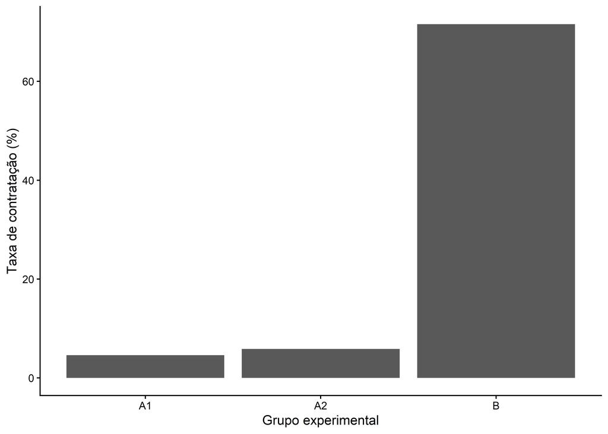

Figura 1: Taxas de contratação do seguro por grupo experimental

```r
# Compara as taxas de contratação dos três grupos em porcentagem.
ggplot2::ggplot(
  resumo_grupos,
  ggplot2::aes(x = treatment, y = 100 * proporcao)
) +
  ggplot2::geom_col() +
  ggplot2::labs(
    x = "Grupo experimental",
    y = "Taxa de contratação (%)"
  ) +
  ggplot2::theme_classic()
```

### Respostas

**a)** A unidade de observação é o agricultor associado a parcela, a variável que representa a contratação do seguro é `tookup` e as variáveis utilizadas para identificar as modalidades de tratamento são `treatment`, `A2` e `B`. A variável `fid1` representa um identificador para qual agrupamento administrativo aquele agricultor pertence e as variáveis dummy `A2` e `B` assumem valor zero para agricultores pertencentes a A1 por ela ser a categoria de referência.

**b)** O número de agricultores em cada grupo de proposta é parecido, com diferenças pequenas e aproximadamente 200 em cada. A partir do gráfico, podemos observar que a taxa de contratação no grupo B, de aproximadamente 72%, é muito maior comparado aos grupos A1 e A2, de aproximadamente 5% e 6% respectivamente, observando um padrão de maior contratação na modalidade do grupo B.

## Questão 2 — Identificação causal

A atribuição aleatória distribui os agricultores entre os grupos independentemente de características individuais, tornando-os comparáveis (na maioria das vezes). Isso reduz o viés de seleção, comum em estudos observacionais, nos quais características dos indivíduos podem influenciar tanto a escolha do tratamento quanto a decisão de contratação. Assim, as diferenças nas taxas de contratação podem ser interpretadas como efeitos causais das modalidades de seguro.

## Questão 3 — Estimação e interpretação do efeito do desconto

A função `fixest::feols()` estima o modelo por mínimos quadrados ordinários. `data` informa a base utilizada, e `vcov = "iid"` solicita os erros-padrão convencionais adotados na atividade. Mantenha esses argumentos preenchidos como estão.

```r
# Complete apenas os nomes das variáveis na fórmula do modelo sem efeitos fixos.
# Estima por MQO as diferenças de contratação em relação ao grupo A1.
modelo_linear <- fixest::feols(
  tookup ~ A2 + B,
  data = dados_seguro,
  vcov = "iid"
)
```

Após completar e executar a célula de código (chunk) anterior, execute o código abaixo sem alterações.

```r
# Calcula as estimativas e os intervalos de confiança do modelo.
estimativas_lineares <- broom::tidy(
  modelo_linear,
  conf.int = TRUE,
  conf.level = 0.95
)

# Exibe as estimativas e as medidas de incerteza.
estimativas_lineares
```

```
# A tibble: 3 × 7
  term        estimate std.error statistic  p.value conf.low conf.high
  <chr>          <dbl>     <dbl>     <dbl>    <dbl>    <dbl>     <dbl>
1 (Intercept)   0.0459    0.0228     2.01  4.46e- 2  0.00112    0.0907
2 A2            0.0126    0.0319     0.396 6.93e- 1 -0.0500     0.0753
3 B             0.670     0.0319    21.0   1.04e-73  0.607      0.732
```

Na linha `A2`, a coluna `estimate` apresenta o coeficiente estimado, e `conf.low` e `conf.high` apresentam os limites inferior e superior do intervalo de confiança de 95%. Multiplique esses três valores por 100 para expressá-los em pontos percentuais.

### Respostas

**a)** O coeficiente estimado de A2 é 0,0126, indicando que a oferta do seguro com pagamento antecipado e desconto de 30% apresentou uma probabilidade de contratação aproximadamente 1,26 ponto percentual maior em relação à oferta com pagamento antecipado integral

**b)** O intervalo de confiança de 95% do coeficiente de A2 vai de, aproximadamente, -5,00 a 7,53 pontos percentuais, incluindo o valor zero no intervalo. Assim, não é possível descartar a hipótese de que o efeito do desconto sobre a contratação seja nulo ($\beta = 0$). Portanto, não há evidências estatísticas para afirmar que o desconto de 30% aumentou ou reduziu a probabilidade de contratação em relação ao grupo A1.

## Questão 4 — Diferenças de médias e regressão linear

### Calcula a diferença entre as proporções

Reutilizamos `resumo_grupos`, criado na Questão 1. `filter()` seleciona uma linha e mantém a estrutura de tabela, `pull(proporcao)` extrai os valores da coluna `proporcao` como um vetor numérico. Como cada seleção contém uma única linha, obtemos um valor para cada modalidade. `pull()` extrai a proporção já calculada, sem recalculá-la.

Primeiro, mostramos separadamente a seleção e a extração para o pagamento na colheita (`B`).

```r
# Seleciona a linha com as estatísticas do grupo B.
grupo_b <- resumo_grupos |>
  filter(treatment == "B")

# Exibe a tabela selecionada.
grupo_b
```

```
# A tibble: 1 × 6
# Groups:   treatment, A2 [1]
  treatment    A2     B agricultores contratacoes proporcao
  <chr>     <dbl> <dbl>        <int>        <dbl>     <dbl>
1 B             0     1          204          146     0.716
```

```r
# Extrai a coluna de proporções como um vetor numérico.
proporcao_b <- grupo_b |>
  pull(proporcao)

# Exibe a proporção de contratação do grupo B.
proporcao_b
```

```
[1] 0.7156863
```

Para o pagamento antecipado integral (`A1`), reunimos as duas operações em um pipeline e calculamos a diferença na ordem solicitada no enunciado. A seleção pelos identificadores das modalidades torna o cálculo independente da ordem das linhas na tabela.

```r
# Seleciona o grupo A1 e extrai sua proporção de contratação.
proporcao_a1 <- resumo_grupos |>
  filter(treatment == "A1") |>
  pull(proporcao)

# Subtrai a taxa de A1 da taxa de B.
diferenca_proporcoes <- proporcao_b - proporcao_a1

# Mostra o resultado com quatro casas decimais.
round(diferenca_proporcoes, 4)
```

```
[1] 0.6698
```

### Comparar os resultados pela tabela do modelo

Na tabela `estimativas_lineares`, exibida na Questão 3, consulte a coluna `estimate` na linha identificada por `B` em `term`. Compare essa estimativa com a diferença entre proporções calculada acima, considerando o arredondamento dos valores exibidos.

Para o item **c**, leia também a estimativa da linha `(Intercept)` e some-a ao coeficiente de `B`. Relacione o intercepto e essa soma às proporções observadas nas duas modalidades.

### Respostas

**a)** A diferença entre a proporção de contratação sob pagamento na colheita (B) e a proporção sob pagamento antecipado integral (A1) foi de 0,6698.

**b)** O coeficiente estimado de `B` no modelo da questão 3 foi de 0,66976791 (arredondando 0,6698). Comparando esse valor com a diferença das proporções do item a, podemos observar que são valores arrendondados idênticos, demonstrando que a estimativa de `B` representa a diferença das proporções da contratação de `B` e `A1`.

**c)** O intercepto possui um valor estimado de aproximadamente 0,0459 e, somado ao valor estimado de `B`, chega-se ao valor de 0,7157. O intercepto representa a proporção de contratação sob pagamento antecipado integral (A1) e a soma representa a proporção de contratação sob pagamento na colheita (B), por isso a diferença entre eles representa o coeficiente estimado para `B`. Assim, a oferta com pagamento na colheita apresentou uma taxa de contratação aproximadamente 66,98 pontos percentuais superior à oferta com pagamento antecipado integral.

## Questão 5 — Efeito causal e mecanismos econômicos

Não podemos concluir. O experimento identifica o efeito causal da modalidade de pagamento na colheita sobre a contratação do seguro, mas não permite concluir que as restrições de liquidez sejam a única explicação, podendo ter mecanismos econômicos responsáveis por esse efeito. O resultado também pode estar relacionado às preferências intertemporais dos agricultores e aos riscos percebidos quanto ao cumprimento dos contratos.

## Questão 6 — Efeitos fixos e desenho experimental

`fixef.rm = "none"` preserva as observações dos agrupamentos com um único agricultor, e `vcov = "iid"` mantém a inferência convencional utilizada na reprodução. Complete somente a fórmula e mantenha essas opções.

```r
# Complete apenas os nomes das variáveis na fórmula com efeitos fixos.
# Estima os efeitos dos tratamentos, controlando as diferenças entre agrupamentos.
# Preserva a amostra e utiliza a inferência convencional da especificação original.
modelo_efeitos_fixos <- fixest::feols(
   tookup ~ A2 + B | fid1,
  data = dados_seguro,
  vcov = "iid",
  fixef.rm = "none"
)

# Confere o número de observações utilizadas na estimação.
nobs(modelo_efeitos_fixos)
```

```
[1] 605
```

O código abaixo usa novamente `broom::tidy()`, com os mesmos argumentos da Questão 3, para apresentar os coeficientes e os intervalos de confiança de 95% do modelo com efeitos fixos.

```r
# Organiza os coeficientes e seus intervalos de confiança de 95%.
estimativas_efeitos_fixos <- broom::tidy(
  modelo_efeitos_fixos,
  conf.int = TRUE,
  conf.level = 0.95
)

# Exibe os resultados da especificação com efeitos fixos.
estimativas_efeitos_fixos
```

```
# A tibble: 2 × 7
  term  estimate std.error statistic  p.value conf.low conf.high
  <chr>    <dbl>     <dbl>     <dbl>    <dbl>    <dbl>     <dbl>
1 A2     0.00377    0.0325     0.116 9.08e- 1  -0.0601    0.0677
2 B      0.675      0.0326    20.7   1.24e-66   0.611     0.739
```

### Compara os modelos com `etable()`

Reunimos os dois modelos em uma lista nomeada: cada elemento contém um modelo, e seu nome será o título da coluna correspondente. `fixest::etable()` apresenta seus resultados lado a lado.

`coefstat = "confint"` solicita os intervalos de confiança, e `ci = 0.95` define seu nível. `keep` seleciona os coeficientes de `A2` e `B`; `fitstat = ~ n + ar2` inclui o número de observações e o $R^2$ ajustado. Os demais argumentos ajustam as casas decimais, os rótulos e a apresentação da tabela. `knitr::kable()` apresenta no HTML o `data.frame` produzido por `etable()`. Execute todo o código abaixo sem alterações.

```r
# Define os títulos das colunas e reúne os dois modelos estimados com fixest.
modelos_fixest <- list(
  "Sem efeitos fixos" = modelo_linear,
  "Com efeitos fixos" = modelo_efeitos_fixos
)

# Organiza as estimativas, os intervalos e as estatísticas de ajuste.
tabela_etable <- fixest::etable(
  modelos_fixest,
  coefstat = "confint",
  ci = 0.95,
  keep = c("A2", "B"),
  fitstat = ~ n + ar2,
  digits = "r4",
  digits.stats = "r3",
  signif.code = NA,
  depvar = FALSE,
  se.row = FALSE,
  dict = c("fid1" = "Efeitos fixos", "n" = "n", "ar2" = "R² ajustado"),
  style.df = fixest::style.df(
    fixef.title = "",
    stats.title = "",
    yesNo = c("Sim", "Não")
  )
)

# Exibe no HTML a tabela já organizada por etable.
knitr::kable(tabela_etable)
```

Tabela 1: Contratação do seguro: modelos com e sem efeitos fixos

|  | Sem efeitos fixos | Com efeitos fixos |
| --- | --- | --- |
| A2 | 0.0126 [-0.0500; 0.0753] | 0.0038 [-0.0601; 0.0677] |
| B | 0.6698 [0.6070; 0.7325] | 0.6747 [0.6106; 0.7387] |
| Efeitos fixos | Não | Sim |
| n | 605 | 605 |
| R² ajustado | 0.491 | 0.516 |

Nota: Intervalos de confiança de 95% entre colchetes, calculados com erros-padrão convencionais. A2: desconto de 30%; B: pagamento na colheita. Referência: A1. $n$: número de agricultores. Coeficientes em proporções (×100 = pontos percentuais).

### Respostas

**a)** Os efeitos fixos dos agrupamentos utilizando `fid1` controlam características específicas de cada agrupamento administrativo que podem afetar a decisão de contratação, como condições econômicas e características locais. É pertinente porque a aleatorização foi realizada considerando esses agrupamentos, funcionando como um controle adicional, tornando as comparações mais precisas. Entretanto, a identificação causal dos efeitos dos tratamentos não depende da inclusão dos efeitos fixos, pois é garantida pela atribuição aleatória das modalidades de seguro.

**b)** A inclusão dos efeitos fixos provoca alterações nos coeficientes estimados. Para A2, o coeficiente passa de 0,0126 para 0,0038, reduzindo a diferença estimada em relação ao grupo A1. Para B, o coeficiente passa de 0,6698 para 0,6747, aumentando um pouco a diferença estimada em relação ao grupo A1. As principais conclusões econômicas não se modificam, pois não há evidências estatísticas da diferença entre A2 e A1, enquanto a modalidade B apresenta um pequeno aumento e continua estatisticamente significativo.